# SupplyChain

## Creating LSTM model

```python
import numpy as np
import pandas as pd
from numpy import array
from keras.models import Sequential
from keras.layers import Dense
from keras.layers import LSTM
from keras.layers import Dropout
import matplotlib.pyplot as plt
```

```python
# define model
model = Sequential()
model.add(LSTM(50, activation='relu', input_shape=(n_steps, n_features)))
model.add(Dense(1))
model.compile(optimizer='adam', loss='mse')
```

model = Sequential() : used to stack multiple layers on top of each other. model.add(LSTM(50, activation='relu', input_shape=(n_steps, n_features))): An LSTM layer is added to the model by this line. ReLU serves as the activation function for the 50 memory cells in the LSTM layer, which also accepts a two-dimensional input with 3 time steps and 1 variable for each step and 50 memory cells. model.add(Dense(1)): This line adds a fully connected layer to the model with a single output. model.compile(optimizer='adam', loss='mse'): This line assembles the model, specifying mean squared error as the training loss function and Adam as the optimizer.

```python
# fit model1 for epoch 100
model.fit(X, y_tr, epochs=100, verbose=0)

#Testing model1
y_pred1 = model.predict(X_test)

#Measuring performance using root mean square error
from sklearn.metrics import mean_squared_error
mean_squared_error(y_test, y_pred1, squared=False)
```

```
35278.482900673494
```

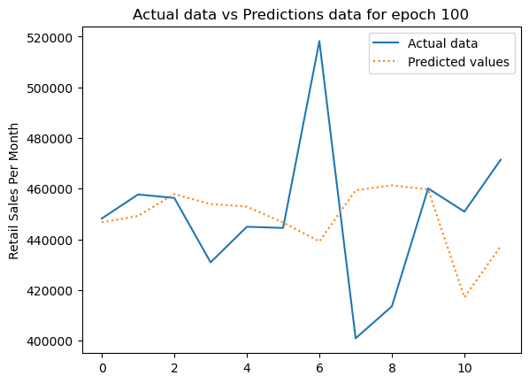

```python
#Plotting actual data & predictions
plt.plot(y_test, label = "Actual data")
plt.plot(y_pred1, label = "Predicted values", linestyle=":")
plt.title("Actual data vs Predictions data for epoch 100")
plt.ylabel("Retail Sales Per Month")
plt.legend()
plt.show()
```

```python
# fit model2 for epoch 50
model.fit(X, y_tr, epochs=50, verbose=0)

#Testing model2
y_pred2 = model.predict(X_test)

#Measuring performance using root mean square error
from sklearn.metrics import mean_squared_error
mean_squared_error(y_test, y_pred2, squared=False)
```

```
35337.96422437826
```

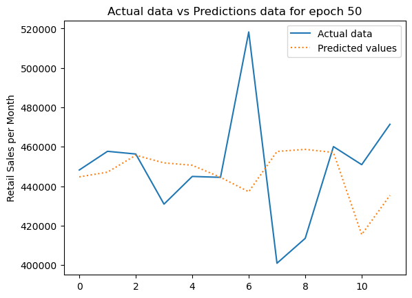

```python
#Plotting actual data & predictions
plt.plot(y_test, label = "Actual data")
plt.plot(y_pred2, label = "Predicted values", linestyle=":")
plt.title("Actual data vs Predictions data for epoch 50")
plt.ylabel("Retail Sales per Month")
plt.legend()
plt.show()
```

```python
# fit model3 for epoch 80
model.fit(X, y_tr, epochs=80, verbose=0)

#Testing model3
y_pred3 = model.predict(X_test)

#Measuring performance using root mean square error
from sklearn.metrics import mean_squared_error
mean_squared_error(y_test, y_pred3, squared=False)
```

```
35017.686614221806
```

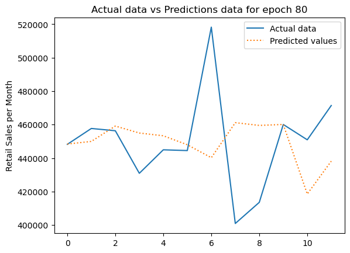

```python
#Plotting actual data & predictions
plt.plot(y_test, label = "Actual data")
plt.plot(y_pred3, label = "Predicted values", linestyle=":")
plt.title("Actual data vs Predictions data for epoch 80")
plt.ylabel("Retail Sales per Month")
plt.legend()
plt.show()
```

While this may seem like a good thing, it is important to note that this may also suggest that the model has overfit the training data and is not able to generalize well to new, unseen data. Therefore, it is important to evaluate the model's performance on a separate validation set to ensure that it is not overfitting.